# Shotgun - Functional Annotation Results

Nate Olson

2018-08-06

```r
library(ProjectTemplate)
load.project()
library(metagenomeSeq)
library(lubridate)
library(readxl)
```

## Loading AR Gene LIST

```r
ar_genes <- read_excel("data/raw_data/ar_tox_genes.xlsx",
                       sheet = 1, range = "B2:C320") %>%
    dplyr::rename(predicted_gene_name = `Relevant genes from ARDB`) %>%
    mutate(predicted_gene_name = toupper(predicted_gene_name)) %>%
    ## Removing duplitate gene names due to letter case differences
    distinct()
```

## Odds Ratio Test

Testing for differences using Odds Ratio test implemented in metagenomeSeq

```r
zv_rw_fun_mrexp <- funct_mrexp[,grepl("(ZVI|RW).*_W", sampleNames(funct_mrexp))]
cl <- pData(zv_rw_fun_mrexp)$Sample_Code
res <- fitDO(zv_rw_fun_mrexp, cl, norm = TRUE, log = FALSE, cores = 6, p = 1)
```

```
## Default value being used.
```

```r
res_df <- rownames_to_column(res, var = "predicted_gene_name")
```

```r
ar_odds_ratio_df <- ar_genes %>% inner_join(res_df)
knitr::kable(ar_odds_ratio_df)
```

| Antibiotic | predicted_gene_name | oddsRatio | lower | upper | pvalues | adjPvalues |
| --- | --- | --- | --- | --- | --- | --- |
| Streptomycin | NORM | 0 | 0.0000000 | Inf | 1 | 1 |
| Chloramphenicol | BLT | 0 | 0.0000000 | Inf | 1 | 1 |
| Chloramphenicol | CEOA | Inf | 0.0256407 | Inf | 1 | 1 |
| Chloramphenicol | MDTL | 0 | 0.0000000 | Inf | 1 | 1 |
| Chloramphenicol | MEXE | 0 | 0.0000000 | Inf | 1 | 1 |
| Chloramphenicol | MEXF | 0 | 0.0000000 | Inf | 1 | 1 |
| Chloramphenicol | OPRN | 0 | 0.0000000 | Inf | 1 | 1 |
| Ciprofloxacin | NORM | 0 | 0.0000000 | Inf | 1 | 1 |
| NA | PMRA | 0 | 0.0000000 | Inf | 1 | 1 |
| Tetracycline | MEXB | 0 | 0.0000000 | Inf | 1 | 1 |
| Tetracycline | OPRM | 0 | 0.0000000 | Inf | 1 | 1 |
| Tetracycline | TETA | 0 | 0.0000000 | Inf | 1 | 1 |
| Tetracycline | TETB | 0 | 0.0000000 | Inf | 1 | 1 |
| Tetracycline | TETV | 0 | 0.0000000 | Inf | 1 | 1 |
| Tetracycline | TETX | 0 | 0.0000000 | Inf | 1 | 1 |
| Erythromycin | MEXC | 0 | 0.0000000 | Inf | 1 | 1 |
| Erythromycin | MEXD | 0 | 0.0000000 | Inf | 1 | 1 |
| Erythromycin | OPRJ | 0 | 0.0000000 | Inf | 1 | 1 |
| Erythromycin | TOLC | 0 | 0.0000000 | Inf | 1 | 1 |
| Penicillin G | PBP1A | 0 | 0.0000000 | Inf | 1 | 1 |
| Penicillin G | PBP1B | 0 | 0.0000000 | Inf | 1 | 1 |
| Penicillin G | PBP2 | 0 | 0.0000000 | Inf | 1 | 1 |
| Penicillin G | PBP2B | 0 | 0.0000000 | Inf | 1 | 1 |
| Vancomycin | VANB | 0 | 0.0000000 | Inf | 1 | 1 |
| Vancomycin | VANA | 0 | 0.0000000 | Inf | 1 | 1 |
| Multidrug Resistance/Multidrug Transporters | LSA | 0 | 0.0000000 | Inf | 1 | 1 |
| Multidrug Resistance/Multidrug Transporters | EMRD | 0 | 0.0000000 | Inf | 1 | 1 |
| Multidrug Resistance/Multidrug Transporters | PMRA | 0 | 0.0000000 | Inf | 1 | 1 |
| Multidrug Resistance/Multidrug Transporters | ACRA | 0 | 0.0000000 | Inf | 1 | 1 |
| Multidrug Resistance/Multidrug Transporters | AMRA | Inf | 0.0256407 | Inf | 1 | 1 |
| Multidrug Resistance/Multidrug Transporters | CEOA | Inf | 0.0256407 | Inf | 1 | 1 |
| Multidrug Resistance/Multidrug Transporters | MEXC | 0 | 0.0000000 | Inf | 1 | 1 |
| Multidrug Resistance/Multidrug Transporters | MEXE | 0 | 0.0000000 | Inf | 1 | 1 |
| Multidrug Resistance/Multidrug Transporters | ACRB | 0 | 0.0000000 | Inf | 1 | 1 |
| Multidrug Resistance/Multidrug Transporters | AMRB | 0 | 0.0000000 | Inf | 1 | 1 |
| Multidrug Resistance/Multidrug Transporters | SMEB | 0 | 0.0000000 | Inf | 1 | 1 |
| Multidrug Resistance/Multidrug Transporters | MEXB | 0 | 0.0000000 | Inf | 1 | 1 |
| Multidrug Resistance/Multidrug Transporters | MEXD | 0 | 0.0000000 | Inf | 1 | 1 |
| Multidrug Resistance/Multidrug Transporters | MEXF | 0 | 0.0000000 | Inf | 1 | 1 |
| Multidrug Resistance/Multidrug Transporters | TOLC | 0 | 0.0000000 | Inf | 1 | 1 |
| Multidrug Resistance/Multidrug Transporters | OPRM | 0 | 0.0000000 | Inf | 1 | 1 |
| Multidrug Resistance/Multidrug Transporters | OPRJ | 0 | 0.0000000 | Inf | 1 | 1 |
| Multidrug Resistance/Multidrug Transporters | OPRN | 0 | 0.0000000 | Inf | 1 | 1 |
| Multidrug Resistance/Multidrug Transporters | EMRE | 0 | 0.0000000 | Inf | 1 | 1 |

## Using metagenomeSeq figZig

```r
zv_rw_fun_mrexp <- funct_mrexp[,grepl("(ZVI|RW).*_W",sampleNames(funct_mrexp))]
pData(zv_rw_fun_mrexp)$Sample_Code <- factor(pData(zv_rw_fun_mrexp)$Sample_Code)

zv_rw_fun_mrexp <- cumNorm(zv_rw_fun_mrexp, p = 0.75)
s <- normFactors(zv_rw_fun_mrexp)
pd <- pData(zv_rw_fun_mrexp)

settings <- zigControl(maxit = 1, verbose = FALSE)
mod <- model.matrix(~Sample_Code+log2(s+1), data = pd)
res = fitZig(zv_rw_fun_mrexp, mod = mod, control = settings, useCSSoffset = FALSE)
funct_stat_tbl <- MRtable(res, coef = 2, number = Inf, group = 3)
```

Multiple test correction for only antibiotics. None of the antibiotics are differentially abundant.

```r
funct_stat_tbl %>% as.data.frame() %>%
    rownames_to_column(var = "predicted_gene_name") %>%
    right_join(ar_genes) %>%
    filter(!is.na(Sample_CodeZVI)) %>%
    mutate(adj.p.values = p.adjust(pvalues,"BH")) %>%
    dplyr::rename(logFC = Sample_CodeZVI) %>%
    select(Antibiotic, predicted_gene_name, logFC, pvalues, adj.p.values) %>%
    knitr::kable()
```

| Antibiotic | predicted_gene_name | logFC | pvalues | adj.p.values |
| --- | --- | --- | --- | --- |
| Streptomycin | NORM | -0.2414384 | 0.6367453 | 0.9781504 |
| Chloramphenicol | BLT | 0.2765107 | 0.5886071 | 0.9781504 |
| Chloramphenicol | CEOA | -0.5753434 | 0.3864945 | 0.9781504 |
| Chloramphenicol | MDTL | 0.0000000 | 1.0000000 | 1.0000000 |
| Chloramphenicol | MEXE | -0.3861418 | 0.4500732 | 0.9781504 |
| Chloramphenicol | MEXF | -0.6230983 | 0.2229306 | 0.9781504 |
| Chloramphenicol | OPRN | -0.4064145 | 0.4266448 | 0.9781504 |
| Ciprofloxacin | NORM | -0.2414384 | 0.6367453 | 0.9781504 |
| NA | PMRA | 0.0000000 | 1.0000000 | 1.0000000 |
| Tetracycline | MEXB | 0.4787330 | 0.3962315 | 0.9781504 |
| Tetracycline | OPRM | -0.2357620 | 0.6446900 | 0.9781504 |
| Tetracycline | TETA | -0.2678534 | 0.6003328 | 0.9781504 |
| Tetracycline | TETB | 0.0000000 | 1.0000000 | 1.0000000 |
| Tetracycline | TETV | 0.0342645 | 0.9465644 | 1.0000000 |
| Tetracycline | TETX | -0.5655240 | 0.3795868 | 0.9781504 |
| Erythromycin | MEXC | 0.0938523 | 0.8763058 | 1.0000000 |
| Erythromycin | MEXD | -0.7457611 | 0.1964964 | 0.9781504 |
| Erythromycin | OPRJ | -0.6013696 | 0.2956774 | 0.9781504 |
| Erythromycin | TOLC | -0.0791990 | 0.8768893 | 1.0000000 |
| Penicillin G | PBP1A | 0.2491098 | 0.6426544 | 0.9781504 |
| Penicillin G | PBP1B | 0.4868770 | 0.4270768 | 0.9781504 |
| Penicillin G | PBP2 | 0.0869685 | 0.8649229 | 1.0000000 |
| Penicillin G | PBP2B | -1.1101878 | 0.0406777 | 0.8949102 |
| Vancomycin | VANB | -0.2861013 | 0.5757422 | 0.9781504 |
| Vancomycin | VANA | 0.3340153 | 0.5135408 | 0.9781504 |
| Multidrug Resistance/Multidrug Transporters | LSA | 0.0000000 | 1.0000000 | 1.0000000 |
| Multidrug Resistance/Multidrug Transporters | EMRD | -0.3464007 | 0.5485441 | 0.9781504 |
| Multidrug Resistance/Multidrug Transporters | PMRA | 0.0000000 | 1.0000000 | 1.0000000 |
| Multidrug Resistance/Multidrug Transporters | ACRA | 0.0498782 | 0.9222801 | 1.0000000 |
| Multidrug Resistance/Multidrug Transporters | AMRA | -0.5753434 | 0.3864945 | 0.9781504 |
| Multidrug Resistance/Multidrug Transporters | CEOA | -0.5753434 | 0.3864945 | 0.9781504 |
| Multidrug Resistance/Multidrug Transporters | MEXC | 0.0938523 | 0.8763058 | 1.0000000 |
| Multidrug Resistance/Multidrug Transporters | MEXE | -0.3861418 | 0.4500732 | 0.9781504 |
| Multidrug Resistance/Multidrug Transporters | ACRB | -0.0899047 | 0.8604085 | 1.0000000 |
| Multidrug Resistance/Multidrug Transporters | AMRB | 0.0000000 | 1.0000000 | 1.0000000 |
| Multidrug Resistance/Multidrug Transporters | SMEB | -1.5992039 | 0.0098007 | 0.4312310 |
| Multidrug Resistance/Multidrug Transporters | MEXB | 0.4787330 | 0.3962315 | 0.9781504 |
| Multidrug Resistance/Multidrug Transporters | MEXD | -0.7457611 | 0.1964964 | 0.9781504 |
| Multidrug Resistance/Multidrug Transporters | MEXF | -0.6230983 | 0.2229306 | 0.9781504 |
| Multidrug Resistance/Multidrug Transporters | TOLC | -0.0791990 | 0.8768893 | 1.0000000 |
| Multidrug Resistance/Multidrug Transporters | OPRM | -0.2357620 | 0.6446900 | 0.9781504 |
| Multidrug Resistance/Multidrug Transporters | OPRJ | -0.6013696 | 0.2956774 | 0.9781504 |
| Multidrug Resistance/Multidrug Transporters | OPRN | -0.4064145 | 0.4266448 | 0.9781504 |
| Multidrug Resistance/Multidrug Transporters | EMRE | 0.1079768 | 0.8327287 | 1.0000000 |

## Plotting diferences

```r
# Create Differential Abundance Table
count_tbl <- MRcounts(zv_rw_fun_mrexp, norm = FALSE, log = FALSE, sl = 1)
# if you want relative abundances
count_tbl <- sweep(count_tbl,2,colSums(count_tbl),"/")


count_tbl <- count_tbl[rownames(count_tbl) %in% ar_genes$predicted_gene_name,]
## removing genes not present in any samples
count_tbl <- count_tbl[rowSums(count_tbl) != 0,]

## Removing genes only observed in one sample
pa_tbl <- count_tbl
pa_tbl[pa_tbl > 0] <- 1
count_tbl <- count_tbl[rowSums(pa_tbl) > 1,]

count_df <- count_tbl %>% as.data.frame() %>%
    rownames_to_column(var = "predicted_gene_name") %>%
    gather("Sample_ID", "prop",-predicted_gene_name) %>% left_join(ar_genes)
count_df <- count_df %>%
    separate(Sample_ID,
             c("Sample_Code", "Collection_Date", "Sample_Type"),
             sep = "_") %>%
    #Fix date format
    mutate(Collection_Date = mdy(paste0(Collection_Date,"-2017")))
```

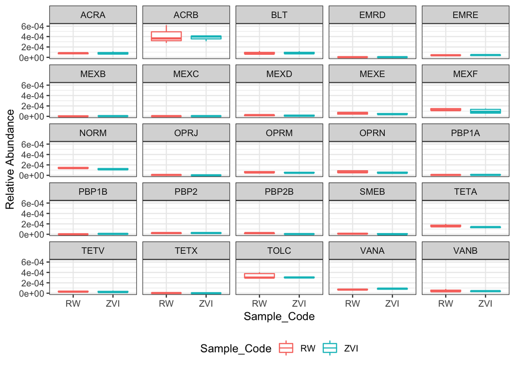

```r
ggplot(count_df) +
    geom_boxplot(aes(x = Sample_Code, y = prop, color = Sample_Code)) +
    facet_wrap(~predicted_gene_name) +
    theme_bw() + labs(y = "Relative Abundance") +
    theme(legend.position = "bottom")
```

Line plots

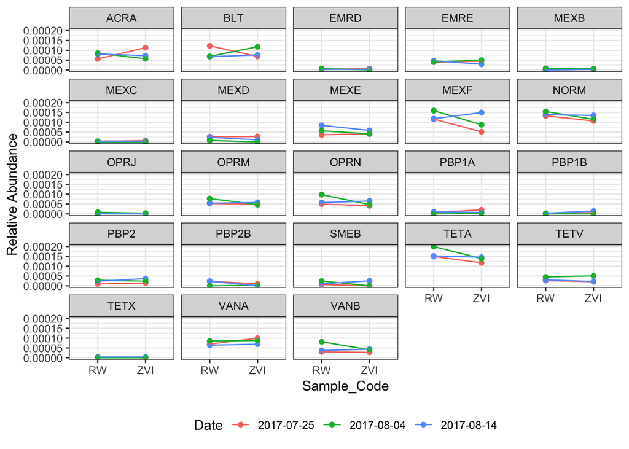

```r
count_df %>% filter(!predicted_gene_name %in% c("ACRB", "TOLC")) %>%
ggplot() +
  geom_point(aes(x = Sample_Code, y = prop,
                 color = factor(Collection_Date))) +
    geom_line(aes(x = as.numeric(as.factor(Sample_Code)),
                  y = prop, color = factor(Collection_Date))) +
    facet_wrap(~predicted_gene_name, ncol = 5) +
    theme_bw() + labs(y = "Relative Abundance") +
  theme(legend.position = "bottom") +
    labs(color = "Date")
```

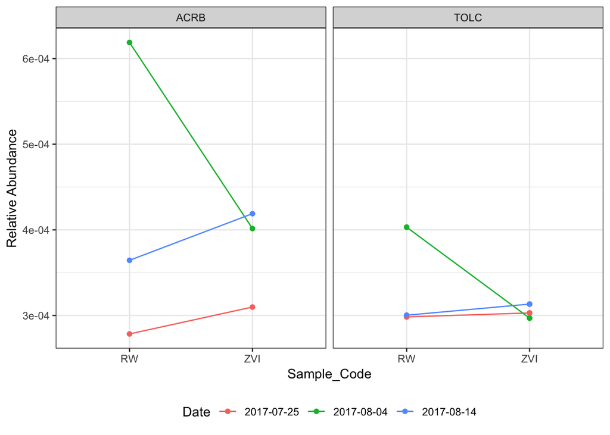

```r
count_df %>% filter(predicted_gene_name %in% c("ACRB", "TOLC")) %>%
ggplot() +
  geom_point(aes(x = Sample_Code, y = prop,
                 color = factor(Collection_Date))) +
    geom_line(aes(x = as.numeric(as.factor(Sample_Code)),
                  y = prop, color = factor(Collection_Date))) +
    facet_wrap(~predicted_gene_name, ncol = 5) +
    theme_bw() + labs(y = "Relative Abundance") +
  theme(legend.position = "bottom") +
    labs(color = "Date")
```

## Gene names

Check gene names from spreadsheet against eggnog mapper predicted gene names. e.g. is AAC the same as AAC2I in the spreadsheet?

## Citation Information

Note citation information from developer

CITATION: If you use this software, please cite:

[1] Fast genome-wide functional annotation through orthology assignment by eggNOG-mapper. Jaime Huerta-Cepas, Kristoffer Forslund, Luis Pedro Coelho, Damian Szklarczyk, Lars Juhl Jensen, Christian von Mering and Peer Bork. Mol Biol Evol (2017). doi: https://doi.org/10.1093/molbev/msx148

[2] eggNOG 4.5: a hierarchical orthology framework with improved functional annotations for eukaryotic, prokaryotic and viral sequences. Jaime Huerta-Cepas, Damian Szklarczyk, Kristoffer Forslund, Helen Cook, Davide Heller, Mathias C. Walter, Thomas Rattei, Daniel R. Mende, Shinichi Sunagawa, Michael Kuhn, Lars Juhl Jensen, Christian von Mering, and Peer Bork. Nucl. Acids Res. (04 January 2016) 44 (D1): D286-D293. doi: https://doi.org/10.1093/nar/gkv1248

[3] Fast and Sensitive Protein Alignment using DIAMOND. Buchfink B, Xie C, Huson DH. 2015. Nat. Methods [Internet] 12.

(e.g. Functional annotation was performed using emapper-0.99.2-3-g41823b2 [1] based on eggNOG orthology data [2]. Sequence searches were performed using [3].)